# Free Software Melbourne Presents

[figure not shown]

[figure not shown]

## Free software as a prerequisite to privacy

### ... and Random Hacks of Kindness

##### Hosting (of various kinds) provided by:

|  |  | System Saviour |  |  | Ben Sturmfels |  |  | Electron Workshop |
| --- | --- | --- | --- | --- | --- | --- | --- | --- |

# Random Hacks of Kindness

[figure not shown]

## About RHoK

- github.com/RHoKAustralia/
- rhokaustralia.org
- Part of a global community of technologists and changemakers who are 'hacking for good'
- Started as a global initiative in 2009 in the US
- In Australia since 2011.
- RHoK events now take place in four locations across the country.
- Australia's largest and longest running hackathon for social good

## RHoK upcoming dates

- Melbourne Information Night: 26th May 2016
- Melbourne Winter Hackathon: 4th and 5th June, 2016
- Winter & Summer hacks

## constitution

- to help build sustainable digital solutions for the purpose of facilitating positive social change
- to build communities of Volunteers where the Volunteers' technical expertise can be deployed and utilised by the wider community to address social challenges and make a real difference
- to build engaged communities of talented, passionate, outcomes-focused hackers
- to organise and deliver events about the "hack for humanity" community in Australia

# Things to do

[figure not shown]

## TPP petition

- reviewed by Federal Parliament right now
- [Petition](https://e-activist.com/ea-action/action?ea.client.id=1965&ea.campaign.id=47139)

## Open Letter to Netflix CEO

- "We need easy, accessible, and effective tools to protect our privacy online while still enjoying the Internet we love – and VPNs do just that"
- [Open Letter](https://act.openmedia.org/netflix?src=159493#letter)

# Government

[figure not shown]

## Productivity Commission to Government: VPN Users Aren't Breaching Copyright

- urges a major overhaul of intellectual property laws
- the Australian Government needs to send a clear message that it is not an infringement of copyright for consumers to be able evade geoblocking technology
- "Making copyright material more accessible and more competitively priced online, and not geoblocking, is the best antidote to copyright infringement"
- Government is also being urged to avoid entering international obligations or trade deals that support restrictions like geoblocking
- "patents and copyright shelf lives for books are no longer relevant to today's internet connected world"
- proposed a change to "fair use" provisions in copyright law, saying the current laws are "too narrow and prescriptive" and don't reflect the way people consume content
- updated fair use provisions would benefit schools, libraries and archives and would "foster certainty" for users
- [Draft report](http://www.pc.gov.au/inquiries/current/intellectual-property/draft)
- [Article](http://www.abc.net.au/news/2016-04-29/geoblocking-consumers-do-not-breach-copyright-by-circumventing/7369714)

## No One Should Have To Use Proprietary Software To Communicate With Their Government

- The FSF urged them to not require people to run proprietary software in order to communicate or submit comments to them
- the Copyright Office requires the use of proprietary JavaScript in order to submit the comment and they are only accepting comments online unless a person lacks computer or Internet access.
- The most absurd part of all this is that other government agencies, while still using Regulations.gov, are perfectly capable of offering alternatives to submission
- [FSF Blog](https://www.fsf.org/blogs/licensing/no-one-should-have-to-use-proprietary-software-to-communicate-with-government)
- [Free Javascript action team](https://libreplanet.org/wiki/Group:Free_Javascript_Action_Team)

## Greenpeace Leaks Big Part Of Secret TTIP Documents

- Transatlantic Trade and Investment Partnership (TTIP) trade talks
- Warns that US corporations may erode Europe's consumer protections
- the US wants to replace the EU's "precautionary principle" for potentially harmful products with the less strict US approach, which aims to manage risks rather than avoid them
- The US permits cultivation of more than 170 GM plants, whereas only one type - a maize variety - is approved for commercial cultivation in the EU
- Greenpeace EU director Jorgo Riss said, "These leaked documents confirm what we have been saying for a long time: TTIP would put corporations at the center of policy-making, to the detriment of environment and public health."
- final TTIP text would require approval by all 28 EU governments and the European Parliament
- [Article](http://www.bbc.com/news/world-europe-36185746)
- [Documents](https://www.ttip-leaks.org/)

# Free Culture

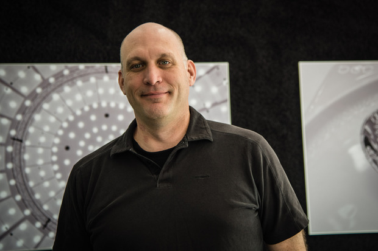

## DuckDuckGo Is Giving Away $225,000 To Support Open Source Projects

- Last year, DuckDuckGo gave away a total of $125,000 to open source projects,
- It also has revenue-sharing agreements with certain companies in the Linux Open Source worlds
- [Article](http://www.businessinsider.com/duckduckgo-is-giving-away-225000-2016-5?IR=T)

## Future of Open Source Survey

- Black Duck Software and venture capital firm North Bridge
- 60 percent of respondents said that open-source participation is a competitive advantage
- 2/3rd said their companies encouraged developers to contribute to open-source projects, and a similar proportion said that they were actively engaged in doing so
- [Article](http://www.networkworld.com/article/3062031/open-source-tools/almost-two-thirds-of-software-companies-contributing-to-open-source.html)

## 'HTML5 By Default' Chrome Setting brings Flash EOL closer

- "disable the playback of Flash content by default, and use HTML5 instead"
- "implement a permanent "Ask to activate" feature for all websites running Flash content"
- ship with Chromium builds in Q4 2016
- allow ten major websites to continue to show Flash content by default without pestering users with "Allow domain.com to run Flash Player" prompts
- whitelist will be in effect one year only
- [Article](http://news.softpedia.com/news/google-devs-planing-flash-s-demise-with-new-html5-by-default-chrome-setting-504048.shtml)

## Linux Is the Largest Software Development Project On the Planet

- Greg K-H
- 4.5 made two months ago contains over 21 million lines of code.
- last year around 4,000 developers and at least 440 different companies that contributed to the kernel
- [YouTube](https://www.youtube.com/watch?v=GGBlBIFAKmA)

## Tech Rocket just published a new interview with Guido van Rossum (the creator of Python)

- "I had a lot of doubts about myself, but Python's ever-increasing success, and encouragement from people to whom I looked up (even Larry Wall!), made me forget that"
- "the most astonishing thing he's seen built with Python is "probaby the Dropbox server"
- "and I really didn’t like Perl 3, which had just come out. So I decided to create my own language instead"
- [Article](http://blog.techrocket.com/2016/04/21/python-creator-guido-van-rossum-on-how-he-got-his-start-in-programming/)

# 🤖 Emojigeddon 🤔

## 'Emojigeddon': The Fight Over The Future Of The Unicode Consortium ... 🍿

- "peculiar and little-known organization that’s unexpectedly been tasked with building what some see as the first digital universal language" 🍾
- the organization's original mission to code old and obscure and minority languages 🗺
- new mission: emojis! 🕴
- “It’s delightful that everyone is so happy about Mr. Colbert, but I can tell you that many people are thinking that the UTC has lost the plot,” 📽🎞
- "yes, obviously a burrito emoji will be more in use than medieval punctuation" 🌯🌮🌭🧀🌶
- his frustrations stem from the consortium’s failure to provide “actionable feedback” on a medieval punctuation proposal that he placed in front of the committee in 2007 🗯 🗨
- Meanwhile, the consortium has accepted 79 new emoji proposals as candidates for its next emoji release 🗃 🗄
- including “drooling face,” “selfie,” “wilted flower,” “croissant,” “stuffed flatbread,” “shallow pan of food,” and “modern pentathlon” (unfortunatly dropped allong with "rifle") ... □ (U+25A1)
- Hudson explained that the reason emoji proposals are causing some consternation inside the Unicode consortium is simply because reviewing them is often easier 🏁
- Are emojis a language? And if not, what exactly are they? Why are their regulation and evolution overseen by a bunch of language nerds and engineers? 🔮
- Adopt an emoji: "We’re devoting the funds raised from the program to help flesh out support for digitally disadvantaged languages" 🔨 📜 📖
- [Article](https://www.buzzfeed.com/charliewarzel/inside-emojigeddon-the-fight-over-the-future-of-the-unicode?utm_term=.jdQz64JLA#.ej15DWvN8)
- [Adopt a character (from as little as $100.00)](http://unicode.org/consortium/adopt-a-character.html)

# Security & Privacy (& Snowden)

[figure not shown]

## Edward Snowden: leaking information about wrongdoing is a vital act of resistance

- "what begins as a survival strategy ends with the compromise of the human being it sought to preserve and the diminishing of the democracy meant to justify the sacrifice"
- not all leaks are alike, nor are their makers
- "By preying on the modern necessity to stay connected, governments can reduce our dignity to something like that of tagged animals, the primary difference being that we paid for the tags and they are in our pockets"
- "surveillance technology has a tendency to follow us home"
- The Assassination Complex: Inside the Government’s Secret Drone Warfare Programme by Jeremy Scahill and the staff of the Intercept, with a foreword by Edward Snowden
- [Article](http://www.theguardian.com/us-news/2016/may/03/edward-snowden-assassination-complex-governments-tagged-animals-drone-warfare-whistleblower)

## Snowden debate with CNN's Fareed Zakaria

- "Encryption saves lives. Encryption protects property. Without it, our economy stops. Our government stops. Everything stops"
- "Lawful access to any device or communication cannot be provided to anybody without fatally compromising the security of everybody"
- [Interview](http://thehill.com/blogs/blog-briefing-room/news/278320-snowden-without-encryption-everything-stops)

## Spy Chief Complains That Edward Snowden Sped Up Spread of Encryption By 7 Years

- 4 if you do the math :p
- shortened timeline has had "a profound effect on our ability to collect, particularly against terrorists,"
- "Of all the things I've been accused of," Snowden said, "this is the one of which I am most proud."
- [Article](https://theintercept.com/2016/04/25/spy-chief-complains-that-edward-snowden-sped-up-spread-of-encryption-by-7-years/)

# Security & Privacy ... not directly related to Snowden

#### (as far as we can tell)

[figure not shown]

## EFF Announces Certbot Client For Let's Encrypt

- the next iteration of the Let's Encrypt client. It's a powerful tool for obtaining TLS/SSL certificates from Let's Encrypt, and (if you wish) automatically installing them to enable and tune HTTPS on your website
- transitioning the client to become an EFF project
- New name, new site & interactive instruction tool
- "Despite the rename and Certbot's new home at EFF, the client will continue to work as it always has"
- [Site](https://certbot.eff.org/)
- [Announce](https://www.eff.org/deeplinks/2016/05/announcing-certbot-new-tls-robot)

## EFF Sues Department of Justice For Access To Secret Court Orders On Decryption

- "filed a lawsuit against the DOJ to reveal documents that show whether it "has ever forced a company like Google or Apple to provide technical surveillance assistance in the Foreign Intelligence Surveillance Court"
- "The suit separately alleges that the agency has failed to turn over other significant FISC opinions that must be declassified as part of surveillance reforms"
- "FISC claimed in a response to EFF that “no responsive applications” for warrants exist"
- "Congress wanted to bring an end to secret surveillance law, so it required that all significant FISC opinions be declassified and released. Our lawsuit seeks to hold DOJ accountable to the law"
- "there’s no question that other, significant FISC opinions remain hidden from the public"
- [Article](http://techcrunch.com/2016/04/19/eff-sues-doj-for-access-to-secret-court-orders-on-decryption/)
- [EFF Press](https://www.eff.org/press/releases/eff-sues-secret-court-orders-requiring-tech-companies-decrypt-users-communications)
- [Full Lawsuit](https://www.eff.org/document/fisc-foia-complaint)

## victory for all who use encryption ...

- ... in the UK
- alleged hacktivist Lauri Love cannot be forced to provide encryption keys to the National Crime Authority
- NCA’s request was widely regarded as an attempt to circumvent the Regulatory of Investigative Powers Act of 2000
- requests of this nature should be governed by RIPA, and not by property legislations
- [Article](https://thestack.com/world/2016/05/10/judge-rules-in-favor-of-hacktivist-love/)

## Shuttleworth Pledges No Back Doors In Linux

- features that we could expect in Ubuntu 16.10, and also talked about security and privacy
- "he said, the move to encryption as a universal expectation is really important. "We don't do encryption to hide things; we do encryption so we can choose what to share,""
- "We will never backdoor Ubuntu; we will never weaken encryption,"
- [Article](http://www.eweek.com/enterprise-apps/ubuntu-founder-pledges-no-back-doors-in-linux.html)

## Canonical's new snap package format is not secure at all when it is used under X.Org Server

- X11's old design is well-known for being insecure
- Matthew Garrett took the time to demonstrate this by writing a simple snap package that can steal data from any other X11 software
- Snap format provides a lot of underlying technology that is a great step towards being able to protect systems ... the protections it provides are easily circumvented
- [Blog](https://mjg59.dreamwidth.org/42320.html)
- [Article](http://news.softpedia.com/news/developer-claims-that-canonical-s-new-snap-format-isn-t-secure-on-ubuntu-desktop-503287.shtml)

# Open Hardware

[figure not shown]

## Linksys WRT Routers Won't Block Open Source Firmware, Despite FCC Rules

- collaborating with chipmaker Marvell and the makers of OpenWrt to make sure its latest WRT routers can comply with the new rules without blocking open source firmware"
- "On and after June 2, newly sold Linksys WRT routers will store RF parameter data in a separate memory location in order to secure it from the firmware"
- "“They're named WRT… it's almost our responsibility to the open source community,” Linksys router product manager Vince La Duca told Ars."
- "Linksys’s method is proprietary and provides a competitive advantage over other router makers that aren’t supporting open source"
- "For Max-Stream devices and other routers that lack WRT branding, “open source is not a value proposition that we are promoting,”"
- "It's not that complicated, it's simply that no one else was prepared for this"
- "experts have urged the router manufacturers to not block open source firmware"
- [Article](http://arstechnica.com/information-technology/2016/05/linksys-wrt-routers-wont-block-open-source-firmware-despite-fcc-rules/)

## Raspbian Linux OS Gets Major Update

- Adds Bluetooth Support to Pi 3 (there is now a Bluetooth plugin for the lxpanel taskbar)
- kernel has been updated to 4.4.
- new backup tool
- new shutdown dialog andmany other minor tweaks
- [Article](http://betanews.com/2016/05/13/raspberry-pi-download-raspbian-linux-update-new/)
- [Announce](https://www.raspberrypi.org/blog/another-update-raspbian/)

## Fathom Neural Compute Stick Offers Artificial Intelligence On A USB Stick

- "Once it's plugged into a Linux-powered device, it will enable that device to perform neural network functions like language comprehension, image recognition, and pattern detection"
- "move AI-level processing from the cloud down to end users"
- [Article](http://www.pcmag.com/news/344130/movidius-unveils-artificial-intelligence-on-a-stick)
- [Site](http://www.movidius.com/solutions/machine-vision-algorithms/machine-learning)

# Releases

[figure not shown]

## BitKeeper Is Open-Sourced

- Eleven years after Linus Torvalds developed Git after a falling out with BitKeeper
- released under the Apache 2.0 license
- BitKeeper continues to be developed as they do still have a corporate following
- [Announce](https://www.phoronix.com/scan.php?page=news_item&px=BitKeeper-Open-Source)
- [Source](https://www.bitkeeper.org/download.html)
- Get it with BitKeeper: bk clone bk://bkbits.net/u/bk/bugfix
- or with free humble pie: git clone https://github.com/bitkeeper-scm/bitkeeper.git

## Google Open-Sources SyntaxNet

- Natural-Language Understanding Library, part of its TensorFlow open source machine learning library
- Parsey McParseface (Google has a sense of humor), which is a pre-trained model for parsing English-language text
- implemented in TensorFlow
- [Announce](http://googleresearch.blogspot.com.au/2016/05/announcing-syntaxnet-worlds-most.html)
- [Article](http://thenextweb.com/dd/2016/05/12/google-just-open-sourced-something-called-parsey-mcparseface-change-ai-forever/)
- [Source](https://github.com/tensorflow/models/tree/master/syntaxnet)

## Open365 is an open source Office 365

- edit or create documents online, and to sync files
- currently in beta (You do get 20 Gigabyte of storage as well right now)
- clients for Windows, Mac or Linux desktop machines, or for Android
- using the technology provided by the Open Source Office suite LibreOffice Online (kde, seafile, docker and jitsi)
- The option to install Open365 on your own server may make it interesting to users who want or need to keep full control of documents
- [Homepage](https://open365.io/)
- [Video](https://www.youtube.com/watch?v=2Xqn14OtcuQ)
- [Announce](http://www.ghacks.net/2016/04/25/open365-office-365-alternative/)

## Mozilla Launches Test Pilot

- A Firefox Add-On For Trying Experimental Features, the new program has been revamped to allow testing of unreleased features
- Activity Stream, Tab Center and Universal Search
- In the works: screenshotting tool and a collaboration with the Internet Archive to make 404 pages more useful
- [Article](http://venturebeat.com/2016/05/10/mozilla-launches-test-pilot-a-firefox-add-on-for-trying-experimental-new-features/)

## Mozilla announced the availability of Firefox in the snap package format for Ubuntu 16.04 LTS

- Having Firefox distributed in the snap format means that you'll have 0-day releases in Ubuntu 16.04
- it looks like the first ever version of the Firefox browser to be offered as a snap package for Ubuntu Linux will be available later this year
- [Article](http://news.softpedia.com/news/mozilla-firefox-web-browser-to-be-available-as-a-snap-package-for-ubuntu-16-04-503269.shtml)
- [Announce](https://blog.mozilla.org/futurereleases/2016/04/21/firefox-default-browser-for-linux-users-ubuntu-new-snap-format-coming-soon/)

## CERN Releases 300TB of Large Hadron Collider Data Into Open Access

- There’s both the raw data from the detectors (so you can verify the results) and also “derived” datasets that are more easy to work with
- "The benefits are numerous, from inspiring high school students to the training of the particle physicists of tomorrow."
- "this is a crucial part of ensuring the long-term availability of our research data"
- CERN is providing tools to work with the data which is handy.
- [Article](http://techcrunch.com/2016/04/22/cern-releases-300tb-of-large-hadron-collider-data-into-open-access/)
- [Thumbdrives Ready](http://opendata.cern.ch/about/CMS)
- Tools
- [GitHub](https://github.com/cms-outreach/ispy-webgl)

## Open Source gym for computer programmers working on artificial intelligence

- run tests in a standardized environment and share their results
- range from robot simulations to Atari games and are designed to develop reinforcement learning
- The environments are written in Python, but we'll soon make them easy to use from any language.
- [Site](https://gym.openai.com/)
- [Announce](https://openai.com/blog/openai-gym-beta/)

## Facebook Open-Sources CTF Competition Platform

- gamified security training platform called Capture the Flag (CTF)
- backend requirements of running a CTF, including the game map, team registration, and scoring
- By open sourcing our platform, schools, student groups, and organizations across all skill levels can now host competitions
- [Announce](http://betanews.com/2016/05/11/facebook-capture-the-flag-open-source/)
- [Source](https://github.com/facebook/fbctf)

## Facebook Announces 'Surround 360' Open Source VR Camera

- 17-lens 3D VR camera, parts can be bought later this summer for about $30,000
- hardware is also coupled with custom software that automatically stitches together video, and permits wireless control
- high-end "reference camera" that the rest of the community could base their designs on
- [Article](http://www.theverge.com/2016/4/12/11395898/facebook-surround-360-video-camera-vr-f8-conference)
- [Announce](https://code.facebook.com/posts/1755691291326688/introducing-facebook-surround-360-an-open-high-quality-3d-360-video-capture-system/)

## Node.js Version 6 Released With LTS

- improved module loading (4x faster), 96% of ECMAScript 2015 features, V8 JavaScript engine 5.0, as well as reliability and security enhancements.
- [Article](http://sdtimes.com/node-js-version-6-released/)

# Distros

[figure not shown]

## Canonical unleashed the highly anticipated Ubuntu 16.04 LTS (Xenial Xerus) operating system

- Kernel 4.4, improved hardware support & RAID 5
- ZFS, Python, snappy, new unity, updated apps
- online search features are now disabled by default
- [Announe](http://www.omgubuntu.co.uk/2016/04/ubuntu-16-04-download-new-features)

## Ubuntu Quietly Raises Install Image Size to 2GB

- some favouring a 2GB (minimally-sized USB stick) hard limit while others are looking to go full-DVD size at 4.7GB
- The current Ubuntu 16.04 LTS desktop .iso is 1.4GB
- "this gives us a new limit that I think we will care about, while also leaving us headroom so we’re not constantly fighting it back down to the line."
- [Article](http://www.omgubuntu.co.uk/2016/05/ubuntu-image-size-increase-2gb)

## ZFS For Linux Lands In Debian Repos

- "currently supporting Arch Linux, Ubuntu, Fedora, Gentoo, Red Hat Enterprise Linux, CentOS, openSUSE, and now Debian"
- "Today, after many years of hard work from many people, ZFS for Linux finally entered Debian"
- DKMS package too
- [ZFS On Linux](http://zfsonlinux.org/)
- [Article](http://news.softpedia.com/news/after-years-of-hard-work-zfs-for-linux-finally-lands-in-debian-gnu-linux-repos-504047.shtml)

## Mesosphere has opted to open-source its data center management platform

- datacenter operating system (DCOS) was built as an operating system for all services in a data center to function as one pool of resources
- some of the company's technologies were already available as open source, others were propriety until now
- [Article](http://www.fiercecio.com/story/data-center-management-darling-mesosphere-embraces-open-source/2016-04-19)
- [Announce](https://mesosphere.com/blog/2016/04/19/open-source-dcos/)